# Module 4: Probabilistic Blocking, Part I

Rebecca C. Steorts

# Agenda

- Data Cleaning Pipeline
- Blocking
- Probabilistic Blocking
- Locality Sensitive Hashing (LSH)
- Jaccard Similarity
- Shingling
- Putting it together
- Limitations

# Load R packages

```r
knitr::opts_chunk$set(echo = TRUE,
                      fig.width=4,
                      fig.height=3,
                      fig.align="center")

if (!require("pacman")) {
  install.packages("pacman")
  library(pacman)
}
p_load(RecordLinkage,blink,knitr,cora,ggplot2,
       textreuse,tokenizers)
```

# Data Cleaning Pipeline

# Blocking

# LSH

Locality sensitive hashing (LSH) is a fast method of blocking for record linkage that orginates from the computer science literature.

# Finding similar records

Our goal is to find *similar* records, where the records are assumed to be strings

How do we define *similar*?

# Jaccard similarity

We will work with the *Jaccard similarity*:
$$Jac(S, T) = \frac{\mid S \cap T\mid}{\mid S \cup T \mid}.$$

# How to represent data as sets?

We want to talk about the similarity of our data (records)$\Rightarrow$ we need to compare sets of records!

- We can construct a set of **short strings** from the data
- This is useful because similar datasets will have many common elements (common short strings)
- We can do construct these short strings using *shingling*

# $k$-shingling (how-to)

1. Think of the data set as a string of characters
2. A $k$-shingle (k-gram) is any sub-string (word) of length $k$ found within the a record of the data set
3. Associate with each data set the set of $k$-shingles that appear one or more times

# Let’s try

Suppose our data set is the string “Hello world”, then

- the set of $2$-shingles is $\{\text{he, el, ll, lo, ow, wo, or, rl, ld}\}$
- the set of $3$-shingles is $\{\text{hel, ell, llo, low, owo, wor, orl, rld}\}$

# Your turn

We have the following two records:

```r
# load RL data
data("RLdata500")

# select only 2 records
records <- RLdata500[129:130, c(1,3)]
names(records) <- c("First name", "Last name")

# inspect records
kable(records)
```

|  | First name | Last name |
| --- | --- | --- |
| 129 | MICHAEL | VOGEL |
| 130 | MICHAEL | MEYER |

# Your turn (continued)

1. Compute the $2$-shingles for each record
2. Using Jaccard similarity, how similar are they?
3. What do you learn from this exercise?

# Your turn solution

**Do this on your own and compare with a partner.**

# Your turn solution

1. The $2$-shingles for the first record are $\{\text{mi, ic, ch, ha, ae, el, lv, vo, og, ge, el}\}$ and for the second are $\{\text{mi, ic, ch, ha, ae, el, lm, me, ey, ye, er}\}$
2. There are 6 items in common $\{\text{mi, ic, ch, ha, ae, el}\}$ and 15 items total $\{\text{mi, ic, ch, ha, ae, el, lv, vo, og, ge, lm, me, ey, ye, er}\}$, so the Jaccard similarity is $\frac{6}{15} = \frac{2}{5} = 0.4$
3. You should have learned that this is very tedious to do by hand!

# Useful packages/functions in `R`

From the exercise, you should have learned that we don’t want to do this by hand!

Here are some useful packages in `R` that can help us!

```r
library(textreuse) # text reuse/document similarity
library(tokenizers) # shingles
```

# Shingling

We can use the following functions to create $k$-shingles and calculate Jaccard similarity for our data

```r
# get n-shingles for a string x
tokenize_character_shingles(x, k)

# calculate jaccard similarity for two sets set1, set2
jaccard_similarity(a, b)
```

# Your turn (solution)

```r
# create shingles for both names
token.1 <-
  tokenize_character_shingles("MICHAELVOGEL", n=2)
token.2 <-
  tokenize_character_shingles("MICHAELMEYER", n=2)
# compute jaccard similarity
jaccard_similarity(unlist(token.1),unlist(token.2))
```

```
## [1] 0.4
```

# Citation Data Set

Research paper headers and citations, with information on authors, title, institutions, venue, date, page numbers and several other fields.

# Citation Data Set

```r
data(cora) # load the cora data set
str(cora) # structure of cora
```

```
## 'data.frame':    1879 obs. of  16 variables:
##  $ id         : int  1 2 3 4 5 6 7 8 9 10 ...
##  $ title      : 'noquote' chr  "Inganas and M.R" NA NA NA ...
##  $ book_title : 'noquote' chr  NA NA NA NA ...
##  $ authors    : 'noquote' chr  "M. Ahlskog, J. Paloheimo, H. Stubb, P. Dyreklev, M. Fahlman, O" "M. Ahlskog, J. Paloheimo, H. Stubb, P. Dyreklev, M. Fahlman, O. Inganas and M.R.   Andersson" "M. Ahlskog, J. Paloheimo, H. Stubb, P. Dyreklev, M. Fahlman, O.  Inganas and M.R.  Andersson" "M. Ahlskog…
##  $ address    : 'noquote' chr  NA NA NA NA ...
##  $ date       : 'noquote' chr  "1994" "1994" "1994" "1994" ...
##  $ year       : 'noquote' chr  NA NA NA NA ...
##  $ editor     : 'noquote' chr  NA NA NA NA ...
##  $ journal    : 'noquote' chr  "Andersson, J Appl. Phys." "JAppl. Phys." "J Appl. Phys." "J Appl.Phys." ...
##  $ volume     : 'noquote' chr  "76" "76" "76" "76" ...
##  $ pages      : 'noquote' chr  "893" "893" "893" "893" ...
##  $ publisher  : 'noquote' chr  NA NA NA NA ...
##  $ institution: 'noquote' chr  NA NA NA NA ...
##  $ type       : 'noquote' chr  NA NA NA NA ...
##  $ tech       : 'noquote' chr  NA NA NA NA ...
##  $ note       : 'noquote' chr  NA NA NA NA ...
```

# Your turn

Using the `title`, `authors`, and `journal` fields in the `cora` dataset,

1. Get the $3$-shingles for each record (**hint:** use `tokenize_character_shingles`)
2. Obtain the Jaccard similarity between each pair of records (**hint:** use `jaccard_similarity`)

# Your turn (partial solution)

```r
# get only the columns we want
# number of records
n <- nrow(cora)
# create id column
dat <- data.frame(id = seq_len(n))
# get columns we want
dat <- cbind(dat, cora[, c("title", "authors", "journal")])
```

# Your turn (partial solution)

**Finish the rest of the exercise with a partner, which can be found after the summary**

# Summary

For a data set of size $n$, the number of comparisons we must compute is
$$\frac{n(n-1)}{2}.$$

For our set of records, we needed to compute $1,764,381$ comparisons For very large data sets, we need something faster (where we filter out records that are not similar). A better approach for data sets of any realistic size is to use *hashing*, which we will look at next time.

# Your turn (Full solution)

```r
# 1. paste the columns together and tokenize for each record
shingles <- apply(dat, 1, function(x) {
  # tokenize strings
  tokenize_character_shingles(paste(x[-1], collapse=" "), n = 3)[[1]]
})
```

# Your turn (Full solution)

```r
# 2. Jaccard similarity between pairs
# empty holder for similarities
jaccard <- expand.grid(record1 = seq_len(n),
                       record2 = seq_len(n))
# don't need to compare the same things twice
jaccard <- jaccard[jaccard$record1 < jaccard$record2,]
time <- Sys.time() # for timing comparison
jaccard$similarity <- apply(jaccard, 1, function(pair) {
  # get jaccard for each pair
  jaccard_similarity(shingles[[pair[1]]], shingles[[pair[2]]])
})
# timing
time <- difftime(Sys.time(), time, units = "secs")
```

This took took $43.77$ seconds $\approx 0.73$ minutes

# Your turn (solution, cont’d)

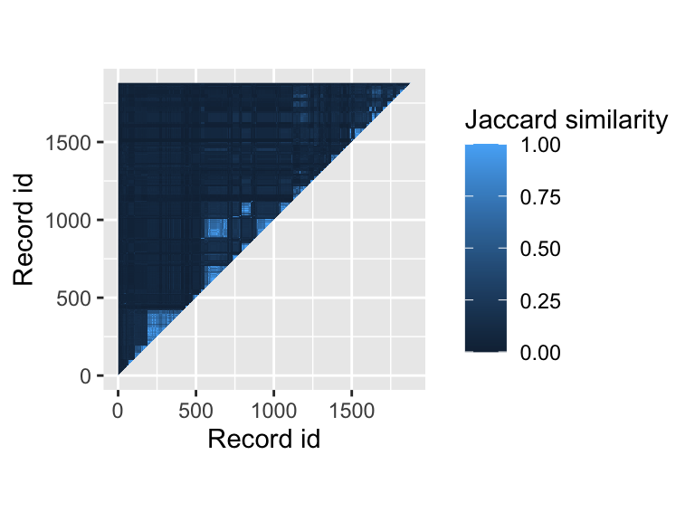

Jaccard similarity for each pair of records. Light blue indicates the two records are more similar and dark blue indicates less similar.

# Jaccard similarity plot

- Are many records similar according to the Jaccard similarity plot (visually)?
- What is problematic in using shingling and the Jaccard similarity (or any sim. score) as a type of blocking?
- Next time, we will consider locality sensitive hashing.

# Takeaways

- Shingling
- Jaccard similarity
- Understanding why these are not practically useful when considering large data sets.